# 3: Introduction to probability

Frank Edwards

## Probability

**How often, on average, does an event occur?**

- Probability is a set of tools for describing randomness.
- Probability helps us sort signal (patterns) from noise.

## Two core theories

*Frequentist:* Probability is the proportion of times an event occurs if we repeat an experiment under the same conditions many times

## Consider a simple experiment

- What is the probability of obtaining a heads on a single fair coin flip?

```r
flip_n_coins<-function(x){
  flip<-rbinom(x, 1, 0.5)
  flip<-ifelse(flip==1, "Heads", "Tails")
  return(flip)
}
```

```r
flip_n_coins(1)
```

```
[1] "Heads"
```

```r
flip_n_coins(1)
```

```
[1] "Heads"
```

```r
flip_n_coins(1)
```

```
[1] "Tails"
```

What is $\frac{\sum_1^n x_i}{n}$ where $x_i=1$ when the coin is heads?

## Probability as the average outcome under repeat experiments

```r
sum((flip_n_coins(5)=="Heads")/5)
```

```
[1] 0.8
```

```r
sum((flip_n_coins(20)=="Heads")/20)
```

```
[1] 0.4
```

```r
sum((flip_n_coins(50)=="Heads")/50)
```

```
[1] 0.56
```

```r
sum((flip_n_coins(1000)=="Heads")/1000)
```

```
[1] 0.473
```

```r
sum((flip_n_coins(100000)=="Heads")/100000)
```

```
[1] 0.50121
```

## Frequentist probability

If $n_x$ is the number of heads, and $n_t$ is the number of coin flips, then the probability of heads is

$$P(x) \approx \frac{n_x}{n_t}$$
$$P(x) = \lim_{n_t\to\infty} \frac{n_x}{n_t}$$

## Bayesian probability

*Bayesian:* Probability is a subjective judgment about the likelihood that an event occurs, with endpoints at 0 (never occurs) and 1 (always occurs).

## Definitions

*Deterministic* processes do not include randomness. For example, if I drop a ball, it will fall (because gravity).

*Stochastic* events include randomness. For example, if I flip a fair coin, it will be heads half of the time.

Nearly all social processes are have random components, and can be treated as *stochastic*.

## Definitions and axioms

- Experiment: an action that produces stochastic events
- Sample space ($\Omega$): a set of all possible outcomes of the experiment
- Event: a subset of the sample space

## Example: coin flips

- Experiment
  1. flip a coin
  2. roll a dice
- Sample space $\Omega$
  1. {Heads, Tails}
  2. {1,2,3,4,5,6}
- Event
  1. Heads, tails, not heads, heads or tails, heads and tails
  2. 3, even number, anything but 6

## Probability axioms

1. The probability of any event A is non-negative: $P(A)\geq0$
2. If an experiment is conducted, the probability that one of the outcomes in the sample space occurs is 1: $P(\Omega)=1$
3. Addition rule: If events A and B are mutually exclusive: $P(A \textsf{ or } B) = P(A) + P(B)$

## Probability that an event doesn’t occur

$$1-P(\textsf{not } A) = P(A)$$

If $P(\textsf{rolling a 6}) = \frac{1}{6}$ then $P(\textsf{not rolling a 6}) = 1 - \frac{1}{6}=\frac{5}{6}$

## Law of total probability

$$P(A) = P(A \textsf{ and } B) + P(A \textsf{ and not } B)$$

Assume the sample space for A is [eats pizza, does not eat pizza], and the sample space for B is [happy, unhappy].

If $P(\textsf{eats pizza}) = 0.5$ and $P(\textsf{eats pizza, happy}) = 0.4$, then $P(\textsf{eats pizza, unhappy}) = 0.1$

## General addition rule

$$P(A \textsf{ or } B) = P(A) + P(B) - P(A \textsf{ and } B)$$

If $P(\textsf{happy})=0.5$, then $P(\textsf{eats pizza or happy})=0.6$

# Three kinds of probability

## Joint probability

The joint probability of two events (A and B) occurring is expressed as

$$P(A \textsf{ and } B)$$

## Marginal probability

The marginal probability of an event B is

$$P(B)$$

## Conditional probability

The conditional probability of event $A$ occurring given that event $B$ occurred is

$$P(A|B) = \frac{P(A \textsf{ and } B)}{P(B)}$$

# Working with some real data

## Voter files

```r
data("FLVoters")
voters<-na.omit(FLVoters)
head(voters)
```

```
     surname county VTD age gender  race
1     PIEDRA    115  66  58      f white
2      LYNCH    115  13  51      m white
4    LATHROP    115  80  54      m white
5     HUMMEL    115   8  77      f white
6 CHRISTISON    115  55  49      m white
7      HOMAN    115  84  77      f white
```

## Marginal probability

What is the probability that a randomly sampled voter in the population is Black: $P(Black) = ?$

```r
voters |>
  count(race) |>
  mutate(p = n/sum(n))
```

```
      race    n           p
1    asian  175 0.019203336
2    black 1194 0.131021617
3 hispanic 1192 0.130802151
4   native   29 0.003182267
5    other  310 0.034017338
6    white 6213 0.681773291
```

Is a woman: $P(Woman)= ?$

```r
voters |>
  count(gender) |>
  mutate(p = n/sum(n))
```

```
  gender    n         p
1      f 4883 0.5358279
2      m 4230 0.4641721
```

## Joint probability

What is the probability that a voter is a Black woman: $P(\textsf{Black and woman}) = ?$

```r
voters |>
  count(gender, race) |>
  mutate(n = n/sum(n)) |>
  pivot_wider(names_from = gender, values_from = n)
```

```
# A tibble: 6 × 3
  race           f       m
  <chr>      <dbl>   <dbl>
1 asian    0.00911 0.0101
2 black    0.0744  0.0566
3 hispanic 0.0731  0.0577
4 native   0.00187 0.00132
5 other    0.0173  0.0167
6 white    0.360   0.322
```

## What is the probability that a voter is a woman?

```
# A tibble: 6 × 3
  race           f       m
  <chr>      <dbl>   <dbl>
1 asian    0.00911 0.0101
2 black    0.0744  0.0566
3 hispanic 0.0731  0.0577
4 native   0.00187 0.00132
5 other    0.0173  0.0167
6 white    0.360   0.322
```

Use the law of total probability:

$$P(A) = P(A \textsf{ and } B) + P(A \textsf{ and not } B)$$

put differently, for all categories of B $i$:

$$P(A) = \sum_{i=1}^n{P(A \textsf{ and } B_i)}$$

## Conditional probability

If a voter is a man, what is the probability that he is Asian: $P(\textsf{Asian|man})= ?$

```r
voters |>
  filter(gender=="m") |>
  count(race) |>
  mutate(p=n/sum(n))
```

```
      race    n           p
1    asian   92 0.021749409
2    black  516 0.121985816
3 hispanic  526 0.124349882
4   native   12 0.002836879
5    other  152 0.035933806
6    white 2932 0.693144208
```

## Conditioning on more than one variable

What is the probability that a male voter over age 60 is white?

$$P(\textsf{white|male and over 60)}$$

```r
voters |>
  mutate(over60=age>60, white = race=="white") |>
  count(over60, gender, white) |>
  mutate(n=n/sum(n)) |>
  pivot_wider(names_from = gender, values_from = n)
```

```
# A tibble: 4 × 4
  over60 white      f      m
  <lgl>  <lgl>  <dbl>  <dbl>
1 FALSE  FALSE 0.131  0.109
2 FALSE  TRUE  0.212  0.198
3 TRUE   FALSE 0.0449 0.0335
4 TRUE   TRUE  0.148  0.124
```

## Independence

Two events are independent if knowledge of one event gives us no information about the other event.

$P(A|B)=P(A)$ and $P(B|A)=P(B)$

$$A \perp B$$

if and only if

$$P(A \textsf{ and } B) = P(A)P(B)$$

## Bayes’ rule

How should we change our beliefs after we make observations about the world?

$$P(A|B) = \frac{P(B|A)P(A)}{P(B)}$$

## Prior beliefs and evidence

If we have a *prior* belief that event A has $P(A)$ chance of occurring, we observe some data, $B$, we update our beliefs and obtain a *posterior probability* $P(A|B)$.

$$P(A|B) = \frac{P(B|A)P(A)}{P(B)}$$

## Example: Detecting breast cancer

How good is a mammogram at detecting breast cancer?

One percent of women have breast cancer. 80 percent of people who have cancer and take a mammogram test positive. 9.6 percent of mammograms are a false positive

If you take a mammogram and get a positive result, what is the probability that you have breast cancer?

## Rewriting as probabilities

One percent of women have breast cancer

$$P(\textsf{Cancer}) = 0.01$$

80 percent of people who have cancer and take a mammogram test positive

$$P(\textsf{Test positive|Cancer}) = 0.8$$

9.6 percent of people who take a mammogram get a positive result when they do not have breast cancer

$$P(\textsf{Test positive|No cancer}) = 0.096$$

## Using Bayes’ rule

The prior probability of having cancer is 0.01. How should we update our belief that someone has cancer based on a positive test?

$$P(A|B) = \frac{P(B|A)P(A)}{P(B)}$$

Using the law of total probability, we can rewrite the denominator as:

$$P(B) = P(B|A)P(A) + P(B|\textsf{ not A})P(\textsf{not }A)$$

## Using Bayes’ rule

We can apply Bayes’ rule for A = Cancer, B = positive test:

$$P(\textsf{Cancer|Test positive})=$$

$$\frac{P(\textsf{Test positive|Cancer})P(\textsf{Cancer})} {P(\textsf{Test positive)}}$$

$$P(\textsf{Cancer|Test positive})=\frac{0.8 \times 0.01}{0.8 \times 0.01 + 0.096 \times 0.99}$$

```r
(0.8 *  0.01)/(0.8 *  0.01 + 0.096 * 0.99)
```

```
[1] 0.07763975
```

# Random Variables

## Random Variables

- Random variables assign values to events
- Each value is mutually exclusive
- The set of all values is exhaustive (the sample space $\Omega$)
- Discrete random variables take a finite number of values (e.g. TRUE, FALSE)
- Continuous random variables are real numbers, and take on an infinite number of values

## The simplest random variable: the binary Bernoulli

- Any random variable with two values is called a Bernoulli random variable.
- Bernoulli (binary) variables are typically represented as $[0,1]$ or $[T,F]$.

## A coin flip as a Bernoulli random variable

A coin flip can be defined as a discrete random variable $X$

- If the coin lands on heads, $X=1$
- If the coin lands on tails, $X=0$
- The probability of a Bernoulli variable is the probability of success, or $X=1$
- $P(X=1) = p$

## Random variable (probability distribution) notation

$$X \sim Bernoulli(p)$$

Reads: X is a Bernoulli distributed random variable with probability p

## Probability mass

The probability mass function (PMF) of a variable $X$ is defined as the probability that a variable takes on a particular value $x$.

$$PMF(x) = P(X=x)$$

## PMF for a coin flip

$$PMF(X=1)=p=0.5$$

$$PMF(X=0)=1-p=0.5$$

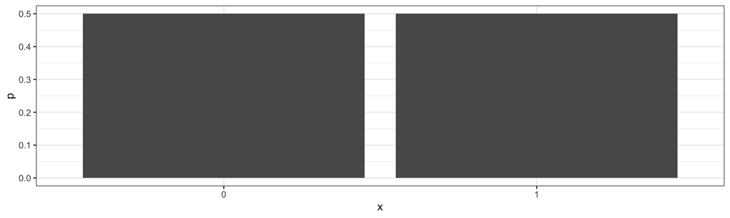

## The probability mass function for passing the bar in NJ (p=0.653)

$$PMF(X=1)=p=0.653$$

$$PMF(X=0)=1-p=0.347$$

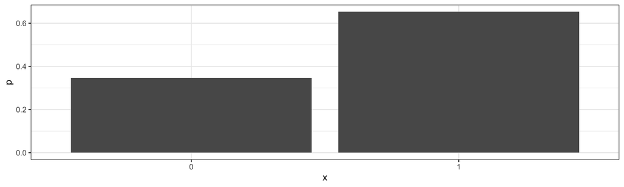

## Describing a probability distribution: cumulative probability

- How likely is a variable to take a value less than or equal to a specified value?
- We define the cumulative distribution function as the sum of all probabilities up to a value x
- $$CDF(X) = P(X \leq x) = \sum_{k \leq x}^x PMF(k)$$
- The CDF always ranges from 0 to 1, and never decreases as $x$ increases.

## Uniform random variables

- Uniform random variables have an equal probability of taking any real value within a given interval $[a,b]$.
- What does $X \sim Uniform(0,10)$ look like?

## Uniform random variables

Let’s simulate it! 10 draws

```r
unif_draws<-runif(10, min=0, max=10)
unif_draws
```

```
 [1] 2.090964 5.376292 3.993732 9.425765 9.704637 1.260444 3.612929 1.832670
 [9] 7.798734 2.021644
```

```r
hist(unif_draws, freq=F)
```

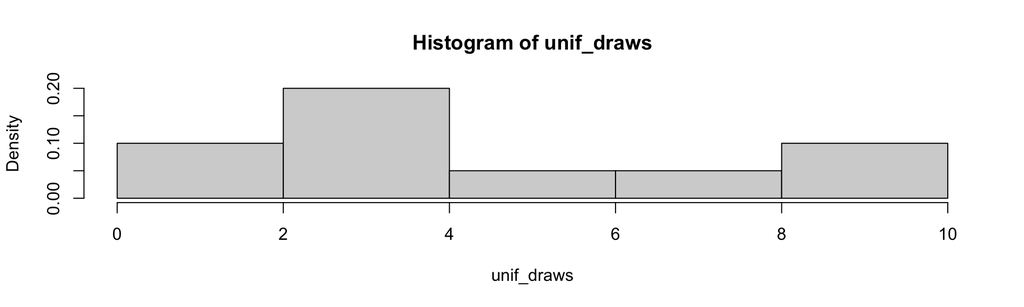

## Uniform random variable: 100 draws

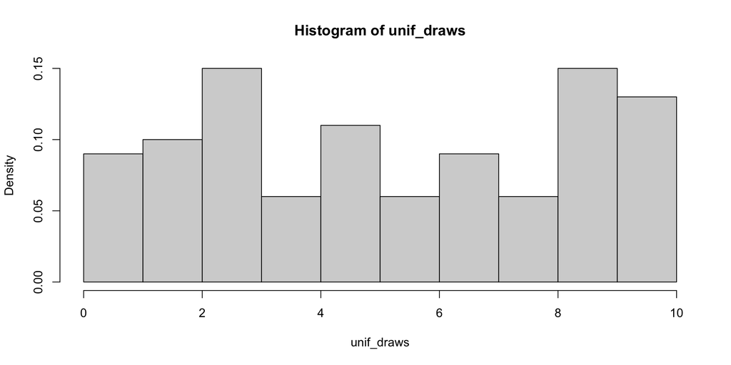

## Uniform random variable: 10000 draws

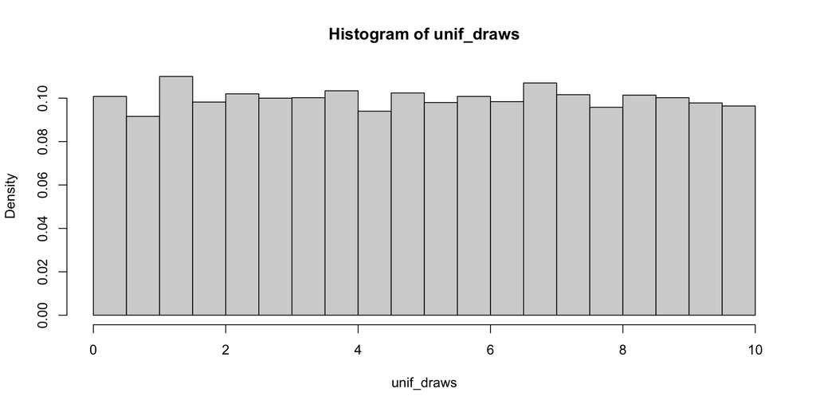

## PDF for $X \sim \textrm{Uniform}(0,10)$

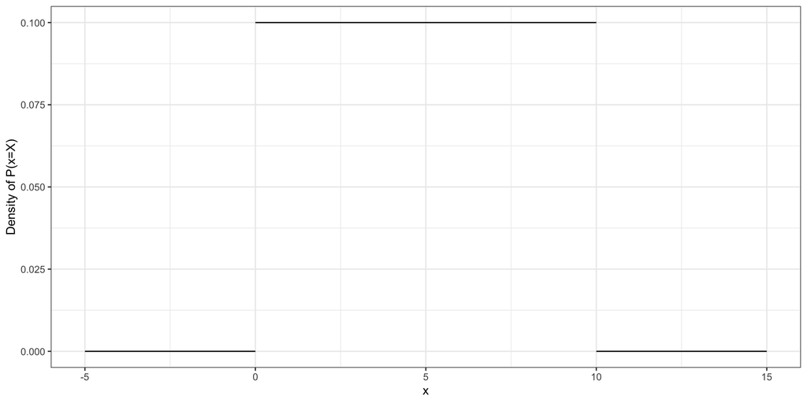

## CDF for $X \sim \textrm{Uniform}(0,10)$

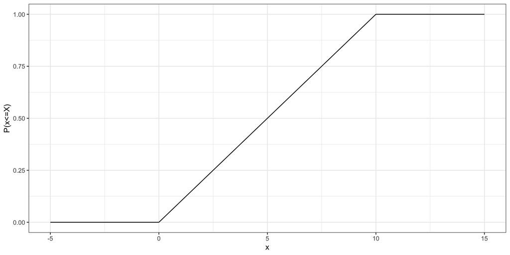

## The expectation of a random variable

- The expectation of a random variable $E(X)$ is the mean of a random variable.
- For a discrete variable, the expectation is the sum of all values of $x$ weighted by their probability, given by the PDF $f(x)$.
- $$E(X) = \sum_x x \times f(x)$$

## Variance and standard deviation

- The standard deviation $sd$ is
- $$sd = \sqrt{\frac{1}{n}\sum_{i=1}^n{(x_i-\bar{x}})^2}$$
- And the sample variance is $sd^2$

## The Normal Distribution

The Normal (Gaussian) distribution is continuous, and takes on values from $[-\infty, \infty]$. It has two parameters, the mean $\mu$ and standard deviation $\sigma$ (or variance $\sigma^2$).

- $\mu$ determines the location of the distribution
- $\sigma$ determines the spread of the distribution

## The Normal PDF

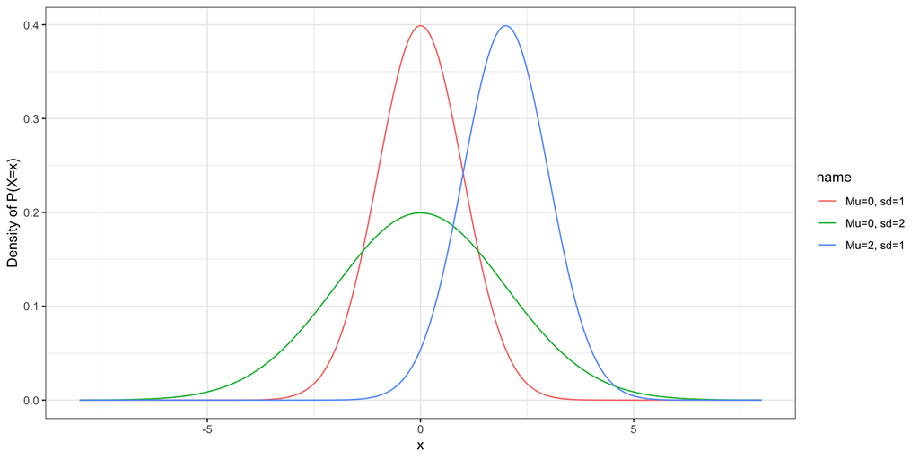

## The Normal CDF

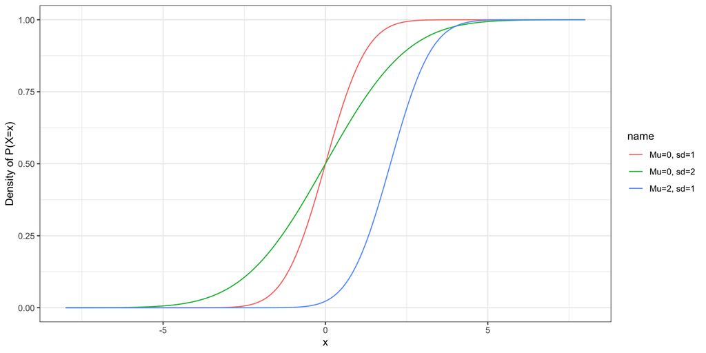

## Special features of Normal distributions:

- The sum of many random variables from other distributions are often Normal
- For $X \sim N(\mu, \sigma^2)$, $Z=X+c$ is also Normal: $Z \sim (\mu +c, \sigma^2)$
- $Z=cX$ is distributed $Z\sim N(c\mu, (c\sigma)^2)$
- Z-scores of a Normal random variable are $N(0,1)$

## Area under the curve: interpreting the PDF and CDF

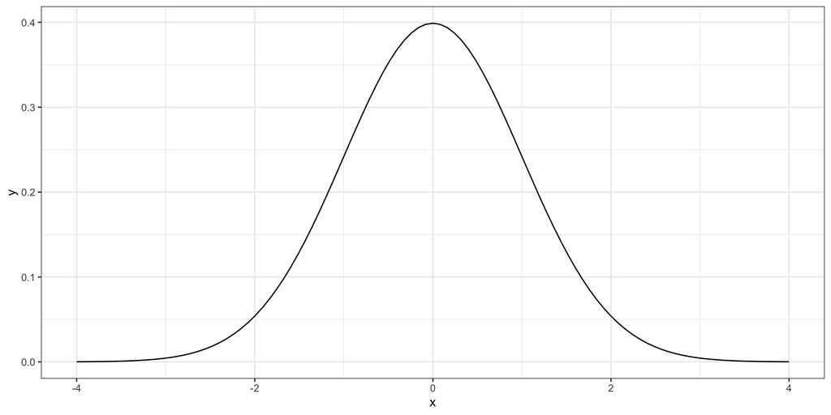

## Area under the curve: interpreting the PDF and CDF

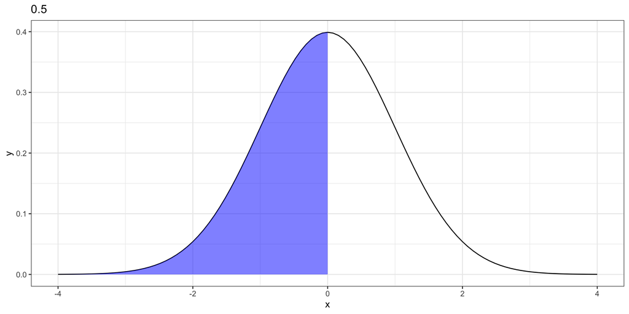

## Area under the curve: interpreting the PDF and CDF

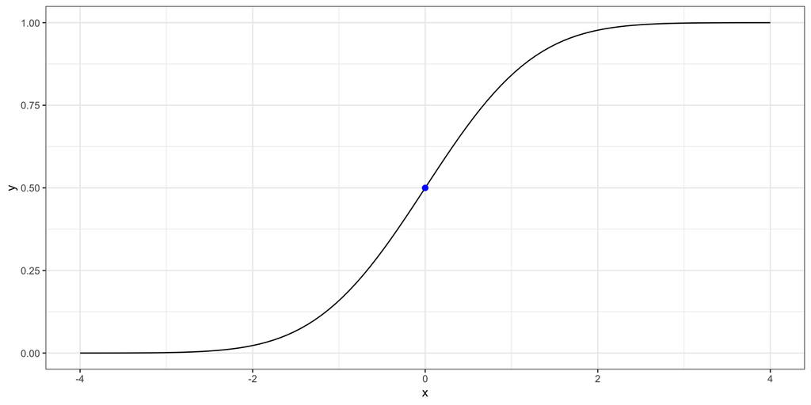

## Area under the curve: interpreting the PDF and CDF

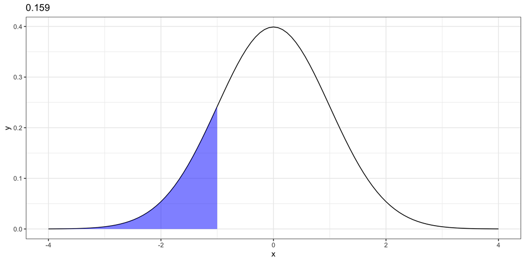

## Area under the curve: interpreting the PDF and CDF

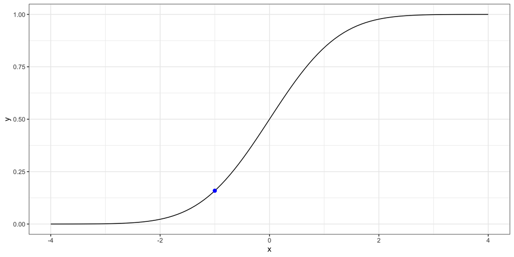

## Z-scores and area under the curve

To obtain a z-score, we subtract the mean and divide by the standard deviation:

$$\textsf{z-score} = \frac{X-\mu}{\sigma}$$

For a Normal variable, z-scores are distributed $z \sim N(0,1)$

What does a z-score of 0 indicate? -1? 2?

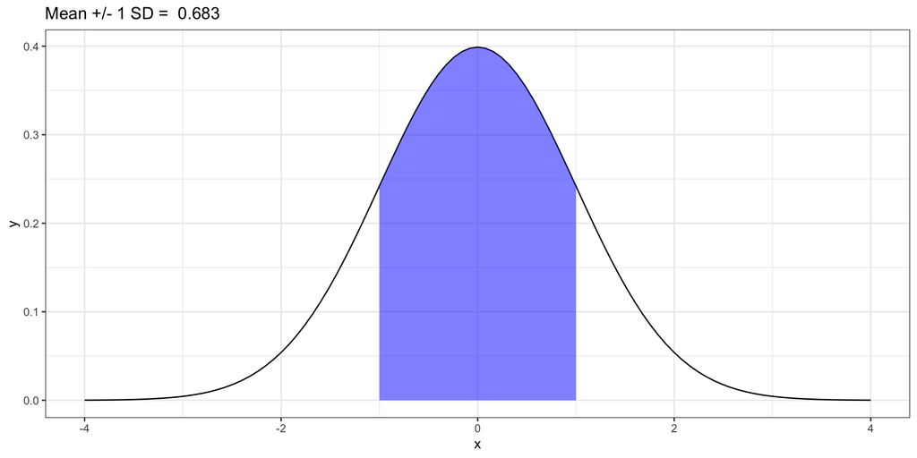

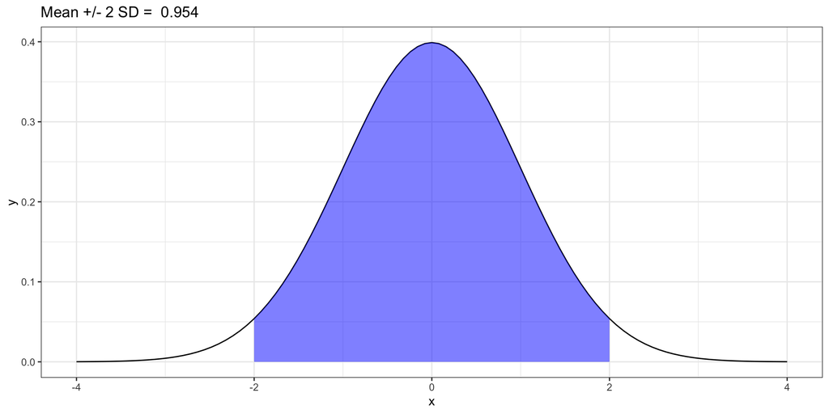

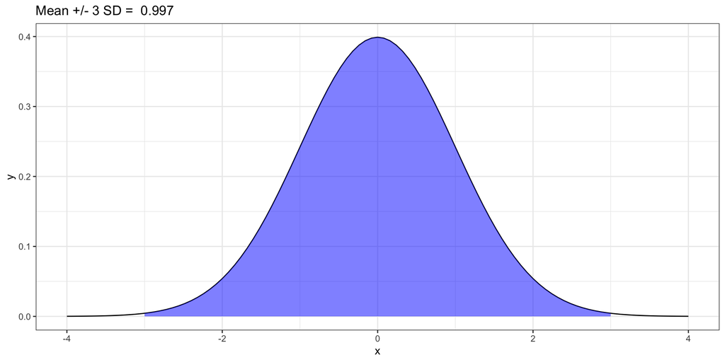

## Useful probability distribution functions

```r
### Normal(0,1) probability density function
dnorm(x = 0, mean = 0, sd = 1)
```

```
[1] 0.3989423
```

```r
### Normal(0,1) cumulative distribution function
pnorm(q = 0, mean = 0, sd = 1)
```

```
[1] 0.5
```

```r
### Random draw from a normal(0,1) distribution
rnorm(n = 1, mean = 0, sd = 1)
```

```
[1] 0.7995289
```

```r
### CDF position for a given probability (quantile)
qnorm(p = 0.75, mean = 0, sd = 1)
```

```
[1] 0.6744898
```

```r
### You can also use dbinom(), pbinom(), rbinom(), qbinom()
```